# Exercises Session III: Description and between-group comparisons

Applied Biostatistics Course with R

Author

Biostatistics Support and Research Unit, IGTP

**Note**

**1.** Read the `divine.xlsx` excel.

**2.** Find:

1. The minimum, 1st quartile (25th percentile), median, mean, 3rd quartile (75th percentile) and maximum of each numerical variable. Also report the missing values for these variables.

**Tip**

The `summary()` function returns all these basic descriptive statistics, along with the number of missing values.

2. Based on these values, which numerical variables are non-normally distributed?

**Tip**

Normally distributed variables should have a median close to the mean. If we find differences, it means that the variable is not normal.

3. Use QQ-Plot to confirm that the other variables are normally distributed.

**Tip**

Normally distributed variables should have points near the diagonal line.

**3.** Describe all the variables stored in this dataset by COVID-19 wave. Report missing values, insert the appropriate labels for each variable, and choose the appropriate statistic for each numeric variable.

**Tip**

tbl_summary() allows you to create a description table for your data. We can change the default labels and statistics with the `label` and `statistic` functions. Remember to use the syntax below:

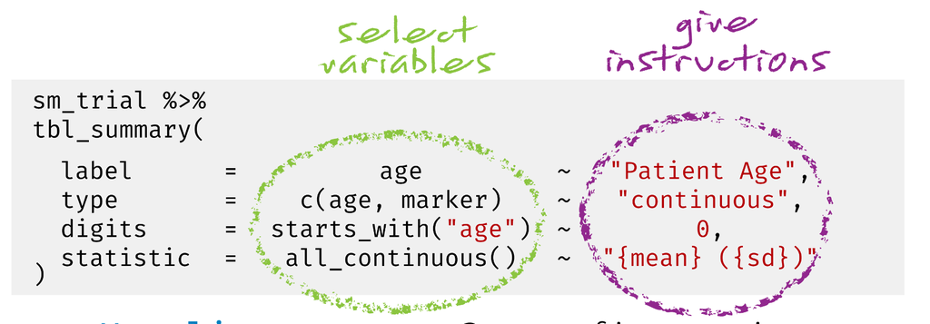

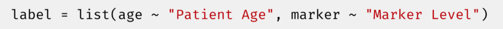

**4.** Compare the proportion of diabetes mellitus by wave:

1. Perform a graphical comparison.

**Tip**

To compare a proportion between groups, it is useful to use the `position = "fill"` argument of the `geom_bar()` function.

2. Perform the appropriate test to determine whether these differences are significant.

**5.** Compare the age distribution by wave:

1. Perform a graphical comparison using a density plot.
2. Repeat it using a box plot.
3. Perform the appropriate test to determine whether there are differences in age between groups.

**Tip**

Check the QQ-plot to determine if this numerical variable is normally distributed or not.

**6.** Compare the total leukocytes by wave:

1. Perform a graphical comparison using a density plot.
2. Repeat it using a box plot.
3. Perform the appropriate test to determine whether these differences are significant.

**Tip**

Check the QQ-plot to determine if this numerical variable is normally distributed or not.

**7.** Perform a comparison test on all variables as a function of the wave and add it to the table.

**Tip**

Use the `add_p()` function after using the `tbl_summary()` function previously used to create the table.

**8.** Compute and interpret the effect size for the variables that showed statistically significant differences between waves. Use Cohen’s D if the variable is numeric and normally distributed. Use relative risk if the variable is categorical. Report the 95% confidence interval for each estimate.